# Midterm Practice

• Is the decomposition additive or multiplicative? STL was fit on the original scale. This fit the additive form: y_t = Trend_t + Seasonal_t + Remainder_t. The seasonal swings look constant in size across time, so it is not growing with the level. This supports an additive decomposition. If seasonality grows with the level, log the series and decompose multiplicatively.

• If seasonal, what are the values of the seasonal monthly indices?

```r
fit_stl <- stl(y_ts, s.window = "periodic", robust = TRUE)
seas <- seasonal(fit_stl)

idx <- tapply(seas, cycle(y_ts), mean)
round(idx, 3)
```

```
##       1       2       3       4
##  -4.884  33.968  20.096 -49.181
```

Seasonally adjusted value = observed − index. Q1 tends to be about $4.9B below the underlying level. Q2 is about $34.0B above the level. Q3 is about $20.1B above the level. Q4 is about $49.2B below the level. The sum is 0 fits the additive seasonality.

• For which month is the time series value high, and for which month is it low? Highest: Q2 index +33.968. Lowest: Q4 index −49.181

• Can you think of the reason behind the high and low values in those months? Q2 becomes higher build-up after Q1. 1. Many firms book strong spring sales; with typical net-30/60 terms, invoices from late Q1 and early Q2 are still outstanding in Q2, lifting receivables. 2. Projects initiated in Q1 often reach billable milestones in Q2, so more invoices are issued and remain open that quarter. Q4 becomes lower for year-end clean-up. 1. Firms push collections before fiscal year-end to improve cash and working-capital metrics, pulling receivables down in Q4. 2. Year-end early-payment discounts and sales/collection targets spur customers to pay faster, further reducing Q4 balances. 3. Companies may write off or provision for doubtful accounts before year-end, trimming reported receivables in Q4.

• Show the plot for the time series adjusted for seasonality. Overlay this with the line for actuals. Does seasonality have big fluctuations in the value of time series?

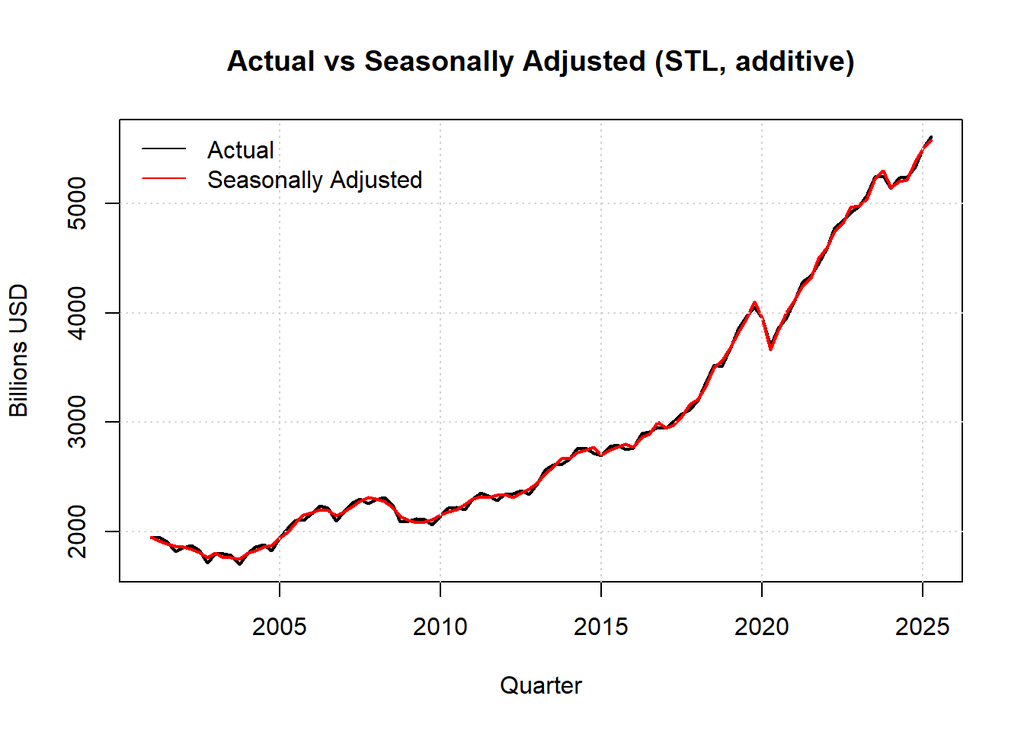

```r
# Decompose and seasonally adjust (additive STL)
fit_stl <- stl(y_ts, s.window = "periodic", robust = TRUE)
y_sa    <- seasadj(fit_stl)

# Plot actual vs seasonally adjusted (overlay)
plot(y_ts, main = "Actual vs Seasonally Adjusted (STL, additive)", ylab = "Billions USD", xlab = "Quarter", lwd = 2)
lines(y_sa, col = "red", lwd = 2)
legend("topleft", c("Actual", "Seasonally Adjusted"), col = c("black","red"), lty = 1, bty = "n")
grid()
```

The seasonally adjusted series is nearly identical to the actuals, so seasonal effects are small relative to the level. Seasonality does not create big swings in this time series.

#Accuracy Summary • Show a table of all the forecast methods above with their accuracy measures.

```r
library(forecast)
naive_forecast <- naive(y_ts, h = 4)
ses_fit <- ses(y_ts, h = 4)
HW_full <- HoltWinters(y_ts); fc_hw <- forecast(HW_full, h = 4)
pick <- c("ME","RMSE","MAE","MPE","MAPE")

naive_row <- as.data.frame(accuracy(naive_forecast))[1, pick, drop = FALSE]
ses_row   <- as.data.frame(accuracy(ses_fit))[1, pick, drop = FALSE]
hw_row    <- as.data.frame(accuracy(fc_hw))[1, pick, drop = FALSE]

acc_tab <- rbind( cbind(Model = "Naive", naive_row), cbind(Model = "SES", ses_row), cbind(Model = "Holt-Winters", hw_row) )

for (nm in pick) acc_tab[[nm]] <- as.numeric(acc_tab[[nm]])
acc_tab[pick] <- lapply(acc_tab[pick], round, 3)
acc_tab
```

```
##                      Model     ME   RMSE    MAE   MPE  MAPE
## Training set         Naive 37.723 88.504 70.903 1.046 2.436
## Training set1          SES 37.341 88.055 70.183 1.035 2.411
## Training set2 Holt-Winters 11.951 74.756 53.810 0.442 1.790
```

• Separately define each forecast method and why it is useful. Show the best and worst forecast method for each of the accuracy measures. 1. Naive (Random Walk): Forecast equals to the last observed value. Why useful: Rock-solid baseline, and is hard to beat on short horizons for unit-root/trending series. 2. Simple Moving Average (SMA): Average of the most recent k observations. Why useful: Smooths short-term noise. Larger k means smoother but slower to react. 3. Simple Exponential Smoothing (SES): Recency-weighted average with weight α on the newest value (no trend/seasonality). Why useful: Adapts to level shifts while keeping noise down, good behavior when pattern is level + noise. 4. Holt-Winters (HW): Exponential smoothing with level α, trend β, and seasonality γ. Why useful: Handles trending and seasonal data, typically more accurate than SES/Naive on upward trends.

Best vs. worst by accuracy measure: Lower is better for RMSE, MAE, MAPE. For ME/MPE, closer to 0 is better.

ME (bias): Best: Holt–Winters 11.951 Worst: Naive 37.723

RMSE: Best: Holt-Winters 74.756 Worst: Naive 88.504

MAE: Best: Holt-Winters 53.810 Worst: Naive 70.903

MPE (% bias): Best: Holt-Winters 0.442% Worst: Naive. Llargest % bias in accuracy output. SES is 1.035% and Naive is higher.

MAPE (% error): Best: Holt-Winters 1.790% Worst: Naive. Largest in the table. SES is 2.411% and Naive is higher.

Summary: Holt-Winters is the most accurate across the board for this dataset. SES is second. Naive is the weakest. A trend-aware smoother has an edge in this data set.

#Conclusion • Summarize your analysis of the time series values over the time period. The series mostly went up. There was a short drop around 2020, then it climbed faster to new highs. The seasonal pattern by quarter is small. Most of the movement is from the long-run trend, not seasonality.

• Based on your analysis and forecast above, do you think the value of the time series will increase, decrease, or stay flat over the next year? How about the next 2 years? Based on the forecasts, the value is expected to increase over the next year. It is also likely to keep increasing over the next two years, although the uncertainty grows the farther out we look.

• Rank forecasting methods for this time series based on historical values. 1. Holt-Winters: best accuracy and smallest bias. 2. Simple Exponential Smoothing (SES): good, but not as strong as Holt–Winters. 3. Naive: weakest on this trending series; useful only as a simple benchmark. 4. The simple moving averages are helpful for smoothing the line, but they react slowly and are not as accurate for forecasting in this case.